# Lab 7

Univariate Statistics with R

This week we’ll be merging data collected from a number of sources before running a simple correlation and a linear model. You should end up knowing a bit more about data manipulation, as well as about running statistical tests. As always, create a new project in RStudio.

## Aperitif: `merge()` and missing values

**Task 1:** First of all, generate a data frame with IQ measurements for 5 people (Amos, Bill, Chas, Dave, and Earl). (**Hint:** Remember that IQ is a normally distributed variable with $Mean = 100$ and $SD = 15$.)

```
  name        iq
1 Amos  80.00194
2 Bill 120.17541
3 Chas 103.97025
4 Dave 124.94289
5 Earl 103.71343
```

**Task 2:** Next, create another data frame with height measurements for 5 people (Bill, Dave, Earl, Fred, and Greg).

```
  name   height
1 Bill 182.1303
2 Dave 211.3598
3 Earl 180.1156
4 Fred 155.3442
5 Greg 175.3764
```

You’ll notice that the data frames you’ve created contain partially overlapping information (some of the names). If you wanted to test for a relationship between IQ and height[^1] it would be useful to create one merged data frame. Perhaps predictably, the `R` function for this is `merge()`:

**Task 3:** Try the following commands:

```r
merge(iq.f, ht.f)
  name       iq   height
1 Bill 120.1754 182.1303
2 Dave 124.9429 211.3598
3 Earl 103.7134 180.1156
merge(iq.f, ht.f, all = T)
  name        iq   height
1 Amos  80.00194       NA
2 Bill 120.17541 182.1303
3 Chas 103.97025       NA
4 Dave 124.94289 211.3598
5 Earl 103.71343 180.1156
6 Fred        NA 155.3442
7 Greg        NA 175.3764
```

What do the different versions do? What would you do if the columns in each data frame had different names? (Try `?merge`).

**Task 4:** Now create a new merged data frame (note, this command is slightly different again):

```r
new.f <- merge(iq.f, ht.f, all.x = T)
new.f
  name        iq   height
1 Amos  80.00194       NA
2 Bill 120.17541 182.1303
3 Chas 103.97025       NA
4 Dave 124.94289 211.3598
5 Earl 103.71343 180.1156
```

**Task 5:** Calculate the means of the different relevant columns. *Revision: The first two calculations do the same thing (why?)*

```r
mean(new.f$iq)
[1] 106.5608
mean(new.f[ ,2])
[1] 106.5608
```

**Task 6:** Now calculate the mean `height`:

### Missing Values

`mean(new.f$height)` doesn’t give you a mean; instead it returns `NA`. If you completed last weeks worksheet you will have encountered `NA` values and perhaps learned to deal with them. The fact that `R` returns `NA` rather than ignoring any `NA`s in the values given may seem dumb at first (why can’t it ignore the missing values?) but in fact it’s based on an important principle: *You should know your data and you should know that there are missing values, and tell `R`.* If it ‘silently’ dealt with missing values, you could end up with meaningless results through not checking your data properly.

For simple functions (like `mean()`, `sd()`, etc.) *the only way to get `R` to ignore `NA`s is as follows* (`na.rm` can be read as “`NA` remove”):

```r
mean(new.f$height, na.rm = T)
[1] 191.2019
```

For more complicated functions (like `lm()`, which we’ll meet below) there is a general default behaviour called `na.omit` which deletes missing values prior to calculation.

## Starter: A useful function

In the extra file from Week 6, you learnt to write functions; in Lab 3, you learnt about logical subsetting (where items in a vector or matrix are selected according to the logical values `T` or `F`). Can we put these together here?

Write a function called `outliers()` to test whether any of the elements passed to it are greater than, or less than, `x` standard deviations from the mean (where `x` is a value passed to the function). You should use a template something like the following:

```r
outliers <- function(obs, x = 2.5) {
 # code goes here
}
```

**Tip:** Your function takes two values: `obs` (a vector or matrix of observations), and `x`, as above. `x = 2.5` passes a *default value* to `x`: If you don’t specify an explicit value, the default will be used. This means that you can use `outliers(vec)` to find elements in a vector more than 2.5 sds from the mean; or `outliers(vec, 2)` if you prefer 2 sds from the mean.

**Task 7:** Now write the code to complete the function:

**Hint:** Suppose you have a matrix `mat`. The code the replaces those of its elements whose value is an outlier with `NA`s could look something like this: `mat[mat > mean(mat) + 2 * sd(mat)] <- NA`

Here, you’re being asked to produce a function that does something similar to the code inside the `[]` above. You want to use `x` rather than `2` so that the number of standard deviations can be arbitrary and you need to take into account that your input could include `NA`s.

You also need to think about detecting values that are ‘x’ standard deviations *below* the mean in addition to those above it.

**Pro tip:** A neat solution to this problem might involve using the `abs()` function which converts values to their absolute value. See `?abs`, also for more on what an absolute value is, look [here](https://www.mathsisfun.com/numbers/absolute-value.html).

**Task 8:** Test your `outliers` function with the following code: Does it correctly identify the 2 outliers?

```r
vec <- rnorm(20, 100, 15)
vec[sample(length(vec), 2)] <- 250 # create two outliers at random
vec # inspect vector to find outliers
 [1]  90.21218 132.05268 103.39998 250.00000 106.09940  71.68061 103.54545
 [8]  91.46694  96.33894  82.81656  87.66680 106.84111  80.96235  89.40778
[15]  91.11157  87.11206  93.28785 108.71977  88.37341 250.00000
which(outliers(vec)) # check outliers function
[1]  4 20
```

## Main Course: Some data manipulation

The aim of this exercise is for you to load some data, get it into a suitable format for analysis, and perform (for now) a simple correlation, and a linear regression.

*Note:* Most of this exercise is about getting data into shape: Doing the stats is easy!

**Task 9:** Download the data from the LEARN (lab7.Rdata), and load it into `R`.

**Tip:** This data is in `R` format, not `.csv` (because it contains several data frames). If you know how, save it into your project folder. Use one of the commands below to load it into `R`:

```r
load('lab7.Rdata') # if your data is in your project folder
```

**Tip:** The first thing you should do when you’ve loaded your data is look at the `Environment` tab in Rstudio (top right), or type `ls()`, to find out what new objects you’ve loaded.

**Pro tip:** `ls()` returns a list of all the objects (variables and functions) in your workspace. That means it’s very useful if you want to delete everything and start again: You can use `rm(list = ls())` (or if you like pointing and clicking, just click on the broom in RStudio’s Environment tab). `rm()` is the function to **r**e**m**ove things.

You have data from three different Universities on some students in their statistics classes. Each University (or School) has provided you with the same information; unfortunately, they have provided it in slightly different formats. Your task is to assemble all of the information into *one* data frame called `schools`, suitable for further analysis.

The data set should consist of a unique student identifier and, for each student, the school they’re in, their IQ, an exam score, and their gender. Unfortunately, the records are not all complete (in particular, some exam scores are missing), and there may be other errors.

**Tip:** You will definitely want to use `merge()` to tackle this (be careful with the `all` arguments!). You may also be able to use `rbind()` to bind things row-wise as an alternative for some (but not all) merges. You should also be thinking about your indexing skills from previous weeks’ labs. Below are some things you might want to think about:

- are the observations complete?
- are there any typos?
- do the column names match?
- are there any unlikely values, or outliers?

The general approach is probably to fix up (or merge) the data from each individual school, before merging the complete dataset together (*NB.,* you can only merge two things at a time…)

## Side Dish: A note on correlation

```r
x = seq(50, 150, 4)
y = x + rnorm(n = length(x), m = 0, sd = 5) # add some random noise to x and store it in y
y2 = 2 * x + rnorm(n = length(x), m = 0, sd = 10)
y3 = 4 * x + rnorm(n = length(x), m = 0, sd = 20)
```

Take a look at the plot generated below where the black, blue, and red values (and their ‘line of best fit’) represent different variables and their relationship with the variable `x`. Take a second to think about what you expect the correlations between `x` and the three different variables representing `Y` (black, blue, and red) will be.

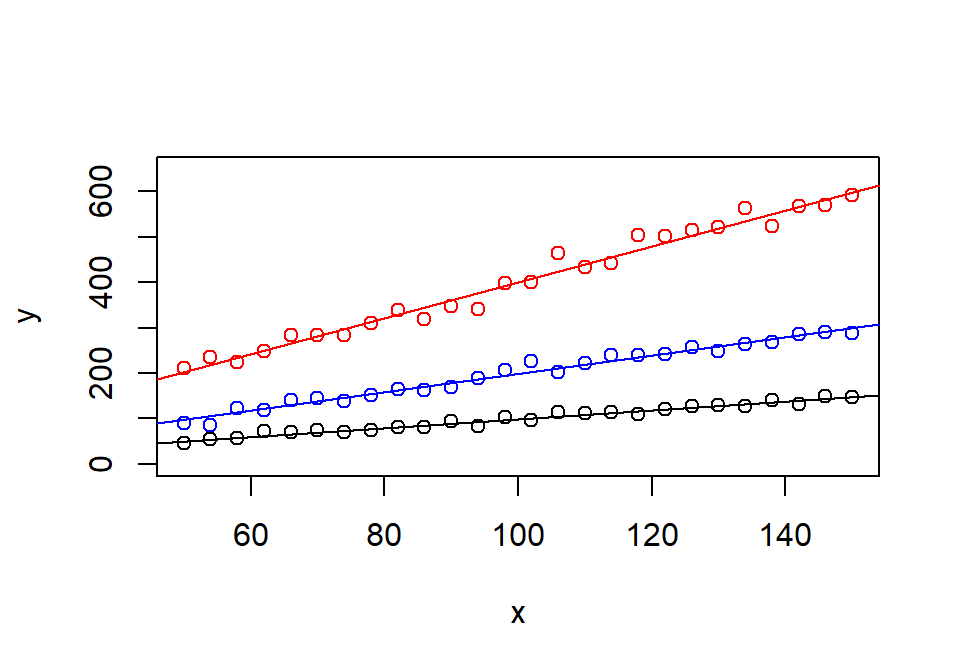

```r
plot(x, y, ylim = c(0, 650))
points(x, y2, col = "blue")
points(x, y3, col = "red")
abline(lm(y ~ x))
abline(lm(y2 ~ x), col = "blue")
abline(lm(y3 ~ x), col = "red")
```

```r
cor(x, y) # Black
[1] 0.9841423
cor(x, y2) # Blue
[1] 0.9887159
cor(x, y3) # Red
[1] 0.9887703
```

Remember that correlation tells you how well the line fits the data (how close the points are to it) and not how steep it is. Looking at all the lines again - you can see that in each case knowing the value of `X` for any one participant allows you to say with almost certainty what their `Y` value would be. The steepness of the gradient is determined by the increase in `Y` units for each one unit increase in `X` - this is the coefficient from the linear model.

## Dessert: Some statistics!

**Task 10:** Using `cor.test()` and `lm()`, run a correlation, and then a linear model, to examine the relationship between IQ and exam performance in the `schools` dataset you’ve just created. What can you conclude from your analyses?

**Tip:** `cor.test()`, and other `R` functions ending in `.test`, are simple functions, designed to do a test and print out information immediately. `lm()` is a bit more complex: The simplest way to start with it is to assign its output to a variable (`var <- lm(...)`) and then use `summary()` to tell you the most useful information about it (`summary(var)`).

```r
# load(url("http://is.gd/tsktsk"))
```

[^1]: This would be a bit silly with 5 observations (and a bit silly anyway!) but it’s just an example.